# Project II- Analysis of Resteraunt Health Inspections in LA

by Nathan Kizlinski

### **Overview of Project**

- Introduction/Project requirements
- Data exploration and cleaning
- Data queries
- Conclusion

### **Introduction/Project requirements**:

With this project, we are asked to apply the knowledge gained from DS 220 into our own analysis project. We are instructed to find real data in any field of our choosing and apply data cleaning to the dataset. We then have to create and run 6-10 queries, and describe our findings. For my project, I decided to delve into inspections for the resteraunt and market industry of Los Angeles County. I chose this dataset becuase I'm from the LA County, and I've also always been very interested in the food industry. I believe that with this project I will able to reach interesting/useful findings that could possibly be beneficial for others.

### **Data exploration/cleaning**:

Before any actual application to the data, we first need to import the dataset into DataFrame. We also need to import the libraries Pandas, Matplotlib, NumPy and Datetime.

```python
from datetime import datetime
import pandas as pd
import matplotlib.pyplot as plt
import numpy as np
data = pd.read_csv('https://raw.githubusercontent.com/nathankizlinski/Project-II/main/Restaurant_and_Market_Health_Inspections.csv')
```

To get all columns of the dataset:

```python
data.columns
```

```
Index(['serial_number', 'activity_date', 'facility_name', 'score', 'grade',
       'service_code', 'service_description', 'employee_id',
       'facility_address', 'facility_city', 'facility_id', 'facility_state',
       'facility_zip', 'owner_id', 'owner_name', 'pe_description',
       'program_element_pe', 'program_name', 'program_status', 'record_id'],
      dtype='object')
```

To see the top 5 rows of the data:

```python
data.head()
```

|  | serial_number | activity_date | facility_name | score | grade | service_code | service_description | employee_id | facility_address | facility_city | facility_id | facility_state | facility_zip | owner_id | owner_name | pe_description | program_element_pe | program_name | program_status | record_id |
| --- | --- | --- | --- | --- | --- | --- | --- | --- | --- | --- | --- | --- | --- | --- | --- | --- | --- | --- | --- | --- |
| 0 | DAJ00E07B | 12/29/2017 12:00:00 AM | HABITAT COFFEE SHOP | 95 | A | 1 | ROUTINE INSPECTION | EE0000923 | 3708 N EAGLE ROCK BLVD | LOS ANGELES | FA0170465 | CA | 90065 | OW0178123 | GLASSELL COFFEE SHOP LLC | RESTAURANT (0-30) SEATS MODERATE RISK | 1631 | HABITAT COFFEE SHOP | ACTIVE | PR0160774 |
| 1 | DAQOKRFZB | 12/29/2017 12:00:00 AM | REILLY'S | 92 | A | 1 | ROUTINE INSPECTION | EE0000633 | 100 WORLD WAY # 120 | LOS ANGELES | FA0244690 | CA | 90045 | OW0208441 | AREAS SKYVIEW LAX JV, LLC | RESTAURANT (0-30) SEATS MODERATE RISK | 1631 | REILLY'S | ACTIVE | PR0193026 |
| 2 | DASJI4LUR | 12/29/2017 12:00:00 AM | STREET CHURROS | 93 | A | 1 | ROUTINE INSPECTION | EE0000835 | 6801 HOLLYWOOD BLVD # 253 | LOS ANGELES | FA0224109 | CA | 90028 | OW0228670 | STREETCHURROS, INC | RESTAURANT (0-30) SEATS LOW RISK | 1630 | STREET CHURROS | ACTIVE | PR0179282 |
| 3 | DA40LU5AT | 12/29/2017 12:00:00 AM | TRINITI ECHO PARK | 94 | A | 1 | ROUTINE INSPECTION | EE0000923 | 1814 W SUNSET BLVD | LOS ANGELES | FA0252528 | CA | 90026-3227 | OW0246287 | AMERICAN HOSPITALITY | RESTAURANT (0-30) SEATS MODERATE RISK | 1631 | TRINITI ECHO PARK | ACTIVE | PR0201836 |
| 4 | DAXV2RMYC | 12/29/2017 12:00:00 AM | POLLEN | 94 | A | 1 | ROUTINE INSPECTION | EE0000923 | 2100 ECHO PARK AVE | LOS ANGELES | FA0252789 | CA | 90026 | OW0246479 | POLLEN AND PASTRY , LLC | RESTAURANT (0-30) SEATS MODERATE RISK | 1631 | POLLEN | ACTIVE | PR0202148 |

To see the last 5 rows of the data:

```python
data.tail()
```

|  | serial_number | activity_date | facility_name | score | grade | service_code | service_description | employee_id | facility_address | facility_city | facility_id | facility_state | facility_zip | owner_id | owner_name | pe_description | program_element_pe | program_name | program_status | record_id |
| --- | --- | --- | --- | --- | --- | --- | --- | --- | --- | --- | --- | --- | --- | --- | --- | --- | --- | --- | --- | --- |
| 67568 | DAZZ4BFUD | 06/15/2018 12:00:00 AM | RAMEN MARUYA | 94 | A | 1 | ROUTINE INSPECTION | EE0000360 | 104 JAPANESE VILLAGE PLZ MALL | LOS ANGELES | FA0159703 | CA | 90012 | OW0124708 | RAMEN MARUYA INC | RESTAURANT (31-60) SEATS HIGH RISK | 1635 | RAMEN MARUYA | ACTIVE | PR0147764 |
| 67569 | DAZZ4TRBY | 05/16/2018 12:00:00 AM | KANG WON DO | 96 | A | 1 | ROUTINE INSPECTION | EE0000723 | 4050 W WASHINGTON BLVD | LOS ANGELES | FA0137540 | CA | 90018 | OW0100601 | KANG WON DO CORPORATION | FOOD MKT RETAIL (2,000+ SF) LOW RISK | 1613 | KANG WON DO | ACTIVE | PR0121641 |
| 67570 | DAZZ9YUS4 | 04/20/2018 12:00:00 AM | OASIS MARKET | 91 | A | 1 | ROUTINE INSPECTION | EE0000594 | 4312 WALL ST | LOS ANGELES | FA0170167 | CA | 90011 | OW0178002 | MCLELLAN INVESTMENTS, LLC | FOOD MKT RETAIL (2,000+ SF) HIGH RISK | 1615 | OASIS MARKET | ACTIVE | PR0160629 |
| 67571 | DAZZJBQUO | 04/17/2018 12:00:00 AM | TEN TEN YU RAMEN | 95 | A | 1 | ROUTINE INSPECTION | EE0000375 | 2012 SAWTELLE BLVD | LOS ANGELES | FA0225467 | CA | 90025 | OW0229730 | WAO, INC. | RESTAURANT (31-60) SEATS HIGH RISK | 1635 | TEN TEN YU RAMEN | ACTIVE | PR0180788 |
| 67572 | DAZZL6GP3 | 06/07/2018 12:00:00 AM | SUPERIOR GROCERS #113 | 97 | A | 1 | ROUTINE INSPECTION | EE0000557 | 3600 E CESAR E CHAVEZ AVE | LOS ANGELES | FA0049848 | CA | 90063 | OW0034460 | SUPER CENTER CONCEPTS, INC | RESTAURANT (0-30) SEATS MODERATE RISK | 1631 | SUPERIOR GROCERS #113 TORTIL | ACTIVE | PR0019416 |

To display the shape of the dataframe:

```python
data.shape
```

```
(67573, 20)
```

As the dataset table seems very large, there are ways to reduce the table to make it easier to read. Based on the project requirements, we can take out some columns that are deemed unneccessary, for example state and city, as all entries are from Los Angeles, California. In the code below, I used the function iloc to return only the wanted columns: serial_number, activity_date, facility_name, score, grade, facility_address, facility_id, facility_zip, owner_id, owner_name, and program_name. Calling the different numbers symbolizes the indexes of the columns I want to include. This can be seen here:

```python
data_cleaned = data.iloc[:,[0,1,2,3,4,8,10,12,13,14,17]].copy()
data_cleaned
```

|  | serial_number | activity_date | facility_name | score | grade | facility_address | facility_id | facility_zip | owner_id | owner_name | program_name |
| --- | --- | --- | --- | --- | --- | --- | --- | --- | --- | --- | --- |
| 0 | DAJ00E07B | 12/29/2017 12:00:00 AM | HABITAT COFFEE SHOP | 95 | A | 3708 N EAGLE ROCK BLVD | FA0170465 | 90065 | OW0178123 | GLASSELL COFFEE SHOP LLC | HABITAT COFFEE SHOP |
| 1 | DAQOKRFZB | 12/29/2017 12:00:00 AM | REILLY'S | 92 | A | 100 WORLD WAY # 120 | FA0244690 | 90045 | OW0208441 | AREAS SKYVIEW LAX JV, LLC | REILLY'S |
| 2 | DASJI4LUR | 12/29/2017 12:00:00 AM | STREET CHURROS | 93 | A | 6801 HOLLYWOOD BLVD # 253 | FA0224109 | 90028 | OW0228670 | STREETCHURROS, INC | STREET CHURROS |
| 3 | DA40LU5AT | 12/29/2017 12:00:00 AM | TRINITI ECHO PARK | 94 | A | 1814 W SUNSET BLVD | FA0252528 | 90026-3227 | OW0246287 | AMERICAN HOSPITALITY | TRINITI ECHO PARK |
| 4 | DAXV2RMYC | 12/29/2017 12:00:00 AM | POLLEN | 94 | A | 2100 ECHO PARK AVE | FA0252789 | 90026 | OW0246479 | POLLEN AND PASTRY , LLC | POLLEN |
| ... | ... | ... | ... | ... | ... | ... | ... | ... | ... | ... | ... |
| 67568 | DAZZ4BFUD | 06/15/2018 12:00:00 AM | RAMEN MARUYA | 94 | A | 104 JAPANESE VILLAGE PLZ MALL | FA0159703 | 90012 | OW0124708 | RAMEN MARUYA INC | RAMEN MARUYA |
| 67569 | DAZZ4TRBY | 05/16/2018 12:00:00 AM | KANG WON DO | 96 | A | 4050 W WASHINGTON BLVD | FA0137540 | 90018 | OW0100601 | KANG WON DO CORPORATION | KANG WON DO |
| 67570 | DAZZ9YUS4 | 04/20/2018 12:00:00 AM | OASIS MARKET | 91 | A | 4312 WALL ST | FA0170167 | 90011 | OW0178002 | MCLELLAN INVESTMENTS, LLC | OASIS MARKET |
| 67571 | DAZZJBQUO | 04/17/2018 12:00:00 AM | TEN TEN YU RAMEN | 95 | A | 2012 SAWTELLE BLVD | FA0225467 | 90025 | OW0229730 | WAO, INC. | TEN TEN YU RAMEN |
| 67572 | DAZZL6GP3 | 06/07/2018 12:00:00 AM | SUPERIOR GROCERS #113 | 97 | A | 3600 E CESAR E CHAVEZ AVE | FA0049848 | 90063 | OW0034460 | SUPER CENTER CONCEPTS, INC | SUPERIOR GROCERS #113 TORTIL |

67573 rows × 11 columns

To start cleaning, we can check the data to see if there's any null values. Using the isnull() and sum() functions will help out with this.

```python
data_cleaned.isnull().sum()
```

```
serial_number        0
activity_date        0
facility_name        0
score                0
grade                3
facility_address     0
facility_id          0
facility_zip         0
owner_id             0
owner_name           0
program_name        29
dtype: int64
```

After seeing that there are 3 entries with no grade, that data isn't very useful and should be discarded. To drop the rows that are useless:

```python
data_cleaned.dropna(how='all', subset=['grade'],inplace=True)
data_cleaned.isnull().sum()
```

```
serial_number        0
activity_date        0
facility_name        0
score                0
grade                0
facility_address     0
facility_id          0
facility_zip         0
owner_id             0
owner_name           0
program_name        29
dtype: int64
```

To check for duplicates:

```python
data_cleaned.duplicated().sum()
```

```
0
```

To check the data types for all columns:

```python
data_cleaned.dtypes
```

```
serial_number       object
activity_date       object
facility_name       object
score                int64
grade               object
facility_address    object
facility_id         object
facility_zip        object
owner_id            object
owner_name          object
program_name        object
dtype: object
```

Next, I sorted the data frame on the column facility name.

```python
data_cleaned.sort_values('facility_name')
```

|  | serial_number | activity_date | facility_name | score | grade | facility_address | facility_id | facility_zip | owner_id | owner_name | program_name |
| --- | --- | --- | --- | --- | --- | --- | --- | --- | --- | --- | --- |
| 12307 | DAJFACZWZ | 02/09/2017 12:00:00 AM | #1 CAFE | 90 | A | 2080 CENTURY PARK E STE 108 | FA0056432 | 90067 | OW0000002 | #1 CAFE INC | #1 CAFE |
| 50490 | DAKGVAKK1 | 09/06/2017 12:00:00 AM | #1 CAFE | 90 | A | 2080 CENTURY PARK E STE 108 | FA0056432 | 90067 | OW0000002 | #1 CAFE INC | #1 CAFE |
| 47090 | DACZXQ74W | 03/01/2018 12:00:00 AM | #1 CAFE | 90 | A | 2080 CENTURY PARK E STE 108 | FA0056432 | 90067 | OW0000002 | #1 CAFE INC | #1 CAFE |
| 51389 | DAM3ZTCJZ | 08/18/2016 12:00:00 AM | #1 CAFE | 90 | A | 2080 CENTURY PARK E STE 108 | FA0056432 | 90067 | OW0000002 | #1 CAFE INC | #1 CAFE |
| 55433 | DATTZTX1J | 05/25/2016 12:00:00 AM | #1 CAFE | 92 | A | 2080 CENTURY PARK E STE 108 | FA0056432 | 90067 | OW0000002 | #1 CAFE INC | #1 CAFE |
| ... | ... | ... | ... | ... | ... | ... | ... | ... | ... | ... | ... |
| 38885 | DA5JNTS3L | 11/03/2017 12:00:00 AM | ZZAMONG | 92 | A | 4255 W 3RD ST | FA0074451 | 90020 | OW0002474 | AMDA ENTERPRISES LLC | ZZAMONG |
| 39360 | DADTI4NE2 | 01/19/2017 12:00:00 AM | ZZAMONG | 92 | A | 4255 W 3RD ST | FA0074451 | 90020 | OW0002474 | AMDA ENTERPRISES LLC | ZZAMONG |
| 39001 | DA8FUHGRW | 09/19/2016 12:00:00 AM | ZZAMONG | 93 | A | 4255 W 3RD ST | FA0074451 | 90020 | OW0002474 | AMDA ENTERPRISES LLC | ZZAMONG |
| 65804 | DATLBDRHD | 07/20/2018 12:00:00 AM | ZZAMONG | 92 | A | 4255 W 3RD ST | FA0074451 | 90020 | OW0002474 | AMDA ENTERPRISES LLC | ZZAMONG |
| 67425 | DAZGXVUUN | 04/04/2018 12:00:00 AM | ZZAMONG | 93 | A | 4255 W 3RD ST | FA0074451 | 90020 | OW0002474 | AMDA ENTERPRISES LLC | ZZAMONG |

67570 rows × 11 columns

The data is now cleaned and ready for analysis.

### **Data queries:**

1. **List all resteraunts with a grade "A", and return the count.**

```python
data_cleaned[data_cleaned['grade']=='A']
```

|  | serial_number | activity_date | facility_name | score | grade | facility_address | facility_id | facility_zip | owner_id | owner_name | program_name |
| --- | --- | --- | --- | --- | --- | --- | --- | --- | --- | --- | --- |
| 0 | DAJ00E07B | 12/29/2017 12:00:00 AM | HABITAT COFFEE SHOP | 95 | A | 3708 N EAGLE ROCK BLVD | FA0170465 | 90065 | OW0178123 | GLASSELL COFFEE SHOP LLC | HABITAT COFFEE SHOP |
| 1 | DAQOKRFZB | 12/29/2017 12:00:00 AM | REILLY'S | 92 | A | 100 WORLD WAY # 120 | FA0244690 | 90045 | OW0208441 | AREAS SKYVIEW LAX JV, LLC | REILLY'S |
| 2 | DASJI4LUR | 12/29/2017 12:00:00 AM | STREET CHURROS | 93 | A | 6801 HOLLYWOOD BLVD # 253 | FA0224109 | 90028 | OW0228670 | STREETCHURROS, INC | STREET CHURROS |
| 3 | DA40LU5AT | 12/29/2017 12:00:00 AM | TRINITI ECHO PARK | 94 | A | 1814 W SUNSET BLVD | FA0252528 | 90026-3227 | OW0246287 | AMERICAN HOSPITALITY | TRINITI ECHO PARK |
| 4 | DAXV2RMYC | 12/29/2017 12:00:00 AM | POLLEN | 94 | A | 2100 ECHO PARK AVE | FA0252789 | 90026 | OW0246479 | POLLEN AND PASTRY , LLC | POLLEN |
| ... | ... | ... | ... | ... | ... | ... | ... | ... | ... | ... | ... |
| 67568 | DAZZ4BFUD | 06/15/2018 12:00:00 AM | RAMEN MARUYA | 94 | A | 104 JAPANESE VILLAGE PLZ MALL | FA0159703 | 90012 | OW0124708 | RAMEN MARUYA INC | RAMEN MARUYA |
| 67569 | DAZZ4TRBY | 05/16/2018 12:00:00 AM | KANG WON DO | 96 | A | 4050 W WASHINGTON BLVD | FA0137540 | 90018 | OW0100601 | KANG WON DO CORPORATION | KANG WON DO |
| 67570 | DAZZ9YUS4 | 04/20/2018 12:00:00 AM | OASIS MARKET | 91 | A | 4312 WALL ST | FA0170167 | 90011 | OW0178002 | MCLELLAN INVESTMENTS, LLC | OASIS MARKET |
| 67571 | DAZZJBQUO | 04/17/2018 12:00:00 AM | TEN TEN YU RAMEN | 95 | A | 2012 SAWTELLE BLVD | FA0225467 | 90025 | OW0229730 | WAO, INC. | TEN TEN YU RAMEN |
| 67572 | DAZZL6GP3 | 06/07/2018 12:00:00 AM | SUPERIOR GROCERS #113 | 97 | A | 3600 E CESAR E CHAVEZ AVE | FA0049848 | 90063 | OW0034460 | SUPER CENTER CONCEPTS, INC | SUPERIOR GROCERS #113 TORTIL |

63134 rows × 11 columns

```python
x = data_cleaned[data_cleaned['grade']=='A']['grade']
x.count()
```

```
63134
```

Observations: By determining the count of resteraunts with a grade of A, and returning the resteraunts, you can tell that there is a lot of safe, clean resteraunts to enjoy in Los Angeles- 63,134 to be exact!

2. **Top 10 resteraunts with the lowest score**

```python
lowest = data_cleaned.sort_values('score',ascending=True)[0:10].copy()
lowest
```

|  | serial_number | activity_date | facility_name | score | grade | facility_address | facility_id | facility_zip | owner_id | owner_name | program_name |
| --- | --- | --- | --- | --- | --- | --- | --- | --- | --- | --- | --- |
| 44918 | DA3R20TAF | 03/14/2017 12:00:00 AM | CHINA WOK | 64 | C | 1527 CRENSHAW BLVD | FA0160005 | 90019 | OW0124991 | LINSANDS BUSINESS INVESTMENT G | CHINA WOK |
| 38970 | DA7M0FRFG | 08/03/2017 12:00:00 AM | NEW FLAVORS | 64 | C | 4135 S CENTINELA AVE | FA0067509 | 90066 | OW0025854 | NEW FLAVORS INC | NEW FLAVORS |
| 34297 | DAVTNZVG3 | 09/28/2015 12:00:00 AM | THREE BEARS BAR-B-Q | 65 |  | 11916 S FIGUEROA ST | FA0002898 | 90061 | OW0001713 | ADAMS,HERMAN L | THREE BEARS BAR-B-Q |
| 46017 | DAABC7FCZ | 09/21/2016 12:00:00 AM | STO. DOMINGO BAKERY | 65 | C | 3418 W 8TH ST | FA0049645 | 90005 | OW0015350 | HERNANDEZ ENRIQUE | STO. DOMINGO BAKERY |
| 39945 | DAL0V00KY | 06/27/2017 12:00:00 AM | VIP CHINESE RESTAURANT | 66 | C | 705 1/2 S WESTERN AVE | FA0054303 | 90005 | OW0036705 | TUNG, JIA CHING | VIP CHINESE RESTAURANT |
| 40238 | DAOKWLHLJ | 10/17/2017 12:00:00 AM | TATSU RAMEN | 66 | C | 2123 SAWTELLE BLVD | FA0050780 | 90025 | OW0025501 | NADEAU, THOMAS | TATSU RAMEN |
| 39644 | DAHATQ9AI | 05/19/2016 12:00:00 AM | MI POBLANITA | 67 | C | 112 E 58TH ST | FA0040525 | 90011 | OW0024045 | MEDINA-PAZOG, PATRICIA | MI POBLANITA |
| 41058 | DAYXMYDJH | 11/21/2015 12:00:00 AM | ANTOJITOS Y GARNACHERIA DONA ROSITA | 68 | C | 6210 S VERMONT AVE | FA0179198 | 90044-3720 | OW0184788 | MARIO ANDRES LOPEZ | ANTOJITOS Y GARNACHERIA DONA ROSITA |
| 40519 | DASDJZFFG | 04/13/2016 12:00:00 AM | SD COFFEE SHOP | 68 | C | 1606 W 6TH ST | FA0032375 | 90017 | OW0022596 | LY SANDY HONG | SD COFFEE SHOP |
| 39634 | DAH3YQM0T | 12/21/2017 12:00:00 AM | YURI'S AUTHENTIC TACOS AND MEXICAN RESTAURANT | 68 | C | 5165 E WHITTIER BLVD | FA0250585 | 90022-3900 | OW0244672 | YURI'S AUTHENTIC TACOS AND MEXICAN RESTAURANT INC | YURI'S AUTHENTIC TACOS AND MEXICAN RESTAURANT |

Observations: By determining the top 10 lowest scores in Los Angeles, it might be best to avoid these resteraunts if one is worried about health issues or resteraunt cleanliness. Resteraunts graded with C are determined to be a public risk and are most likely on the verge of closing.

3. **Display the average score for all SUBWAY resteraunts.**

```python
subway = data_cleaned[data_cleaned['facility_name']=='SUBWAY']
subway_avg = subway['score'].mean()
subway_avg
```

```
95.84516129032258
```

Observations: With an average score of 95.85, it's clear that on average all Subway's in Los Angeles are up to standards with health regulations and safety. No need to be worried when going to an LA Subway!

4. **Display the average ratings of all resteraunts, per year.**

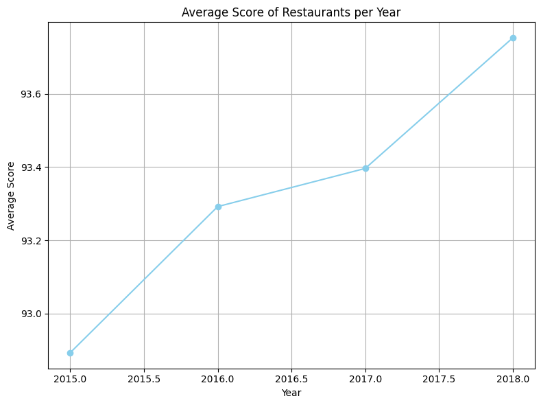

```python
data_cleaned['activity_date'] = pd.to_datetime(data_cleaned['activity_date'], errors='coerce')
data_cleaned['year'] = data_cleaned['activity_date'].dt.year
year_avg = data_cleaned.groupby('year')['score'].mean()


plt.figure(figsize=(8, 6))
plt.plot(year_avg.index, year_avg.values, marker='o', linestyle='-', color='skyblue')
plt.title('Average Score of Restaurants per Year')
plt.xlabel('Year')
plt.ylabel('Average Score')
plt.grid(True)
plt.tight_layout()
plt.show()
```

Observations: Based off the resulting graph above, you can see that each year the average score increases- a relieving trend! It seems as if each year resteraunt health expectations are taken more seriously, possibly with the help of stricter health codes and resteraunt regulations.

5. **Return the average scores of resteraunts with more than 60 locations.**

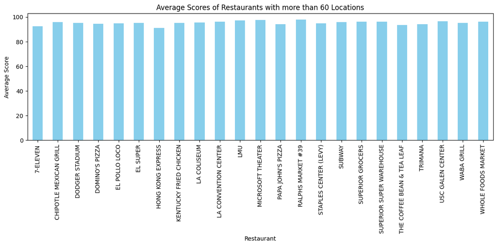

```python
restaurant_count = data_cleaned['facility_name'].value_counts()
many_restaurants = restaurant_count[restaurant_count > 60]

avg = data_cleaned[data_cleaned['facility_name'].isin(many_restaurants.index)]
avg = avg.groupby('facility_name')['score'].mean()


plt.figure(figsize=(12, 6))
avg.plot(kind='bar', color='skyblue')
plt.title('Average Scores of Restaurants with more than 60 Locations')
plt.xlabel('Restaurant')
plt.ylabel('Average Score')
plt.xticks(rotation=90)
plt.tight_layout()
plt.show()
```

Observations: As shown from the graph above, these are the resteraunts with over 60 locations. Determining that all have average scores of at least 90, you can rely on these "big name" brands/resteraunts to have clean facilities and food practices.

6. **Display top 15 rated resteraunts for the zipcode 90022.**

```python
zip = data_cleaned[data_cleaned['facility_zip'] == '90022']
zip_avg = zip.groupby('facility_name')['score'].mean()
top15zip = zip_avg.nlargest(15)

table = pd.DataFrame({
    'restaurant': top15zip.index,
    'score': top15zip.values
})

table
```

|  | restaurant | score |
| --- | --- | --- |
| 0 | LUISA'S PLACE | 100.000000 |
| 1 | $1 CREATIONS | 99.000000 |
| 2 | SUBWAY #63413 | 99.000000 |
| 3 | EAST LOS ANGELES ICE COMPANY | 98.500000 |
| 4 | VALUE EXPRESS | 98.500000 |
| 5 | KENNEDY HALL | 98.333333 |
| 6 | SUBWAY #3707 | 98.333333 |
| 7 | LA PUPUSERIA EL PEPETO | 98.000000 |
| 8 | MEMO'S PLACE | 98.000000 |
| 9 | THE CORK ROOM | 98.000000 |
| 10 | SUBWAY | 97.833333 |
| 11 | EDIBLE ARRANGEMENTS | 97.666667 |
| 12 | LA FIESTA SPORTS BAR | 97.666667 |
| 13 | YUM YUM CHINESE FOOD | 97.571429 |
| 14 | DANIEL'S TACOS | 97.333333 |

Observations: With this query, you can see the top rated resteraunts in a given area (zip code), so if you're visiting or looking for a new spot around town, the resteraunts above would be a great choice.

7. **Display the top 10 owners with the most resteraunts.**

```python
restaurant_owners = data_cleaned.groupby('owner_name')['facility_name'].nunique()
top10 = restaurant_owners.nlargest(10)
top10
```

```
owner_name
STARBUCKS COFFEE CORPORATION              109
GARFIELD BEACH CVS, LLC.                   47
HOST INTERNATIONAL INC                     45
SOUTHERN CALIFORNIA PIZZA CO LLC           30
THRIFTY PAYLESS, INC                       28
JACK IN THE BOX, INC                       24
RALPHS GROCERY COMPANY                     22
ADVANCED FRESH CONCEPTS FRANCHISE CORP     21
YOSHINOYA AMERICA, INC.                    20
EL POLLO LOCO, INC.                        19
Name: facility_name, dtype: int64
```

Observations: With the resulting table shown, its shocking to see how many Starbucks there are in the LA County- 109 locations! If you were to open a buisness in LA, it might be best to avoid starting up a coffee shop, as there is lots of competition from just Starbucks alone.

### **Conclusion:**

With this project, I was able to find a dataset of interest and clean and prepare the raw data for analysis. I was then able to create 7 queries to help aid my insight with the data. With the queries, I was able to infer some observations about the health inspections for resteraunts of the Los Angeles County, and related topics. Datasets such as this are important to understand, as health and safety for everyone should be a top priority that should be taken seriously. I enjoyed working through this project, as I got to practice hands on what I've learned throughout the semster of DS 220.